# World Food

As a person of many talents, it’s time to take on a different job: nutrition analysis! Your goal is to analyze the sugar content of a sample of foods from around the world.

A large dataset called food.csv is ready for your use in the working directory. Instead of the usual read.csv(), however, you’re going to use the faster fread() from the data.table package. By default, the data will come in as a data table, but since you’re used to working with data frames, you can get fread() to return one by setting data.table = FALSE.

```r
# Load data.table
library(data.table)

# Import food.csv as a data frame: food
food <- fread("food.csv", data.table = FALSE)
```

### Examining the data

Let’s get an idea of what the dataset looks like in order to know how to proceed.

```r
# View summary of food
summary(food)
```

```
       V1              code            url              creator            created_t
 Min.   :   1.0   Min.   :100030   Length:1500        Length:1500        Min.   :1.332e+09
 1st Qu.: 375.8   1st Qu.:124975   Class :character   Class :character   1st Qu.:1.394e+09
 Median : 750.5   Median :149514   Mode  :character   Mode  :character   Median :1.425e+09
 Mean   : 750.5   Mean   :149613                                         Mean   :1.414e+09
 3rd Qu.:1125.2   3rd Qu.:174506                                         3rd Qu.:1.436e+09
 Max.   :1500.0   Max.   :199880                                         Max.   :1.453e+09
 created_datetime   last_modified_t     last_modified_datetime product_name
 Length:1500        Min.   :1.340e+09   Length:1500            Length:1500
 Class :character   1st Qu.:1.424e+09   Class :character       Class :character
 Mode  :character   Median :1.437e+09   Mode  :character       Mode  :character
                    Mean   :1.430e+09
                    3rd Qu.:1.446e+09
                    Max.   :1.453e+09
 generic_name         quantity          packaging         packaging_tags
 Length:1500        Length:1500        Length:1500        Length:1500
 Class :character   Class :character   Class :character   Class :character
 Mode  :character   Mode  :character   Mode  :character   Mode  :character



    brands          brands_tags         categories        categories_tags
 Length:1500        Length:1500        Length:1500        Length:1500
 Class :character   Class :character   Class :character   Class :character
 Mode  :character   Mode  :character   Mode  :character   Mode  :character



 categories_en        origins          origins_tags       manufacturing_places
 Length:1500        Length:1500        Length:1500        Length:1500
 Class :character   Class :character   Class :character   Class :character
 Mode  :character   Mode  :character   Mode  :character   Mode  :character



 manufacturing_places_tags    labels          labels_tags         labels_en
 Length:1500               Length:1500        Length:1500        Length:1500
 Class :character          Class :character   Class :character   Class :character
 Mode  :character          Mode  :character   Mode  :character   Mode  :character

```

[output cut: 205 more lines]

```
 collagen_meat_protein_ratio_100g   cocoa_100g   chlorophyl_100g carbon_footprint_100g
 Min.   :12.00                    Min.   :30     Mode:logical    Min.   : 12.00
 1st Qu.:13.50                    1st Qu.:47     NA's:1500       1st Qu.: 97.42
 Median :15.00                    Median :60                     Median :182.85
 Mean   :15.67                    Mean   :57                     Mean   :131.18
 3rd Qu.:17.50                    3rd Qu.:70                     3rd Qu.:190.78
 Max.   :20.00                    Max.   :81                     Max.   :198.70
 nutrition_score_fr_100g nutrition_score_uk_100g
 Min.   :-12.000         Min.   :-12.000
 1st Qu.:  1.000         1st Qu.:  0.000
 Median :  7.000         Median :  6.000
 Mean   :  7.941         Mean   :  7.631
 3rd Qu.: 15.000         3rd Qu.: 16.000
 Max.   : 28.000         Max.   : 28.000
 [ reached getOption("max.print") -- omitted 1 row ]
```

```r
# View head of food
head(food)
```

|  | V1 | code | url | creator | created_t | created_datetime | last_modified_t | last_modified_datetime | product_name | generic_name | quantity | packaging | packaging_tags | brands | brands_tags | categories | categories_tags | categories_en | origins | origins_tags | manufacturing_places | manufacturing_places_tags | labels | labels_tags | labels_en | emb_codes | emb_codes_tags | first_packaging_code_geo | cities | … |
| --- | --- | --- | --- | --- | --- | --- | --- | --- | --- | --- | --- | --- | --- | --- | --- | --- | --- | --- | --- | --- | --- | --- | --- | --- | --- | --- | --- | --- | --- | --- |
| 1 | 1 | 100030 | http://world-en.openfoodfacts.org/product/3222475745867/confiture-de-fraise-fraise-des-bois-au-sucre-de-canne-casino-delices | sebleouf | 1424747544 | 2015-02-24T03:12:24Z | 1438445887 | 2015-08-01T16:18:07Z | Confiture de fraise fraise des bois au sucre de canne |  | 265 g | Bocal,Verre | bocal,verre | Casino Délices | casino-delices | Aliments et boissons Ã base de végétaux,Aliments d'origine végétale,Aliments Ã base de fruits et de légumes,Petit-déjeuners,Produits Ã tartiner,Fruits et produits dérivés,Pâtes Ã tartiner vé… | en:plant-based-foods-and-beverages,en:plant-based-foods,en:fruits-and-vegetables-based-foods,en:breakfasts,en:spreads,en:fruits-based-foods,en:plant-based-spreads,en:sweet-spreads,en:fruit-preserves,e… | Plant-based foods and beverages,Plant-based foods,Fruits and vegetables based foods,Breakfasts,Spreads,Fruits based foods,Plant-based spreads,Sweet spreads,Fruit preserves,Jams,Fruit jams,Berry jams,S… |  |  | France | france |  |  |  | EMB 78015 | emb-78015 | 48.983333,2.066667 | NA | … |
| 2 | 2 | 100050 | http://world-en.openfoodfacts.org/product/5410976880110/guylian-sea-shells-selection | foodorigins | 1450316429 | 2015-12-17T01:40:29Z | 1450817956 | 2015-12-22T20:59:16Z | Guylian Sea Shells Selection |  | 375g | Plastic,Box | plastic,box | Guylian | guylian | Chocolate | en:sugary-snacks,en:chocolates | Sugary snacks,Chocolates |  |  | Belgium | belgium |  |  |  |  |  |  | NA | … |
| 3 | 3 | 100079 | http://world-en.openfoodfacts.org/product/3264750423503/pates-de-fruits-aromatisees-jacquot | domdom26 | 1428674916 | 2015-04-10T14:08:36Z | 1428739289 | 2015-04-11T08:01:29Z | Pâtes de fruits aromatisées | Pâtes de fruits | 1 kg | Carton,plastique | carton,plastique | Jacquot | jacquot | pâtes de fruits | en:plant-based-foods-and-beverages,en:plant-based-foods,en:fruits-and-vegetables-based-foods,en:sugary-snacks,en:confectioneries,en:fruits-based-foods,en:fruit-pastes | Plant-based foods and beverages,Plant-based foods,Fruits and vegetables based foods,Sugary snacks,Confectioneries,Fruits based foods,Fruit pastes |  |  |  |  |  |  |  |  |  |  | NA | … |
| 4 | 4 | 100094 | http://world-en.openfoodfacts.org/product/8006040247001/nata-vegetal-a-base-de-soja-valsoia | javichu | 1420416591 | 2015-01-05T00:09:51Z | 1420417876 | 2015-01-05T00:31:16Z | Nata vegetal a base de soja &quot;Valsoia&quot; | Nata vegetal a base de soja | 200 ml | Tetra Brik | tetra-brik | Valsoia,//Propiedad de://,Valsoia S.p.A. | valsoia,propiedad-de,valsoia-s-p-a | Alimentos y bebidas de origen vegetal,Alimentos de origen vegetal,Natas vegetales,Natas vegetales a base de soja para cocinar,Natas vegetales para cocinar | en:plant-based-foods-and-beverages,en:plant-based-foods,en:plant-based-creams,en:plant-based-creams-for-cooking,en:soy-based-creams-for-cooking | Plant-based foods and beverages,Plant-based foods,Plant-based creams,Plant-based creams for cooking,Soy-based creams for cooking |  |  | Italia | italia | Vegetariano,Vegano,Sin gluten,Sin OMG,Sin lactosa | en:vegetarian,en:vegan,en:gluten-free,en:no-gmos,en:no-lactose | Vegetarian,Vegan,Gluten-free,No GMOs,No lactose |  |  |  | NA | … |
| 5 | 5 | 100124 | http://world-en.openfoodfacts.org/product/8480000340764/semillas-de-girasol-con-cascara-tostadas-aguasal-hacendado | javichu | 1420501121 | 2015-01-05T23:38:41Z | 1445700917 | 2015-10-24T15:35:17Z | Semillas de girasol con cáscara tostadas aguasal | Semillas de girasol con cáscara tostadas aguasal | 200 g | Bolsa de plástico,Envasado en atmósfera protectora | bolsa-de-plastico,envasado-en-atmosfera-protectora | Hacendado,//Propiedad de://,Mercadona S.A. | hacendado,propiedad-de,mercadona-s-a | Semillas de girasol y derivados, Semillas, Semillas de girasol, Semillas de girasol con cáscara, Semillas de girasol tostadas, Semillas de girasol con cáscara tostadas, Semillas de girasol con cásc… | en:plant-based-foods-and-beverages,en:plant-based-foods,en:seeds,en:sunflower-seeds-and-their-products,en:sunflower-seeds,en:roasted-sunflower-seeds,en:unshelled-sunflower-seeds,en:roasted-unshelled-s… | Plant-based foods and beverages,Plant-based foods,Seeds,Sunflower seeds and their products,Sunflower seeds,Roasted sunflower seeds,Unshelled sunflower seeds,Roasted unshelled sunflower seeds,es:Semill… | Argentina | argentina | Beniparrell,Valencia (provincia),Comunidad Valenciana,España | beniparrell,valencia-provincia,comunidad-valenciana,espana | Vegetariano,Vegano,Sin gluten | en:vegetarian,en:vegan,en:gluten-free | Vegetarian,Vegan,Gluten-free | ES 21.016540/V EC,ENVASADOR:,IMPORTACO S.A. | es-21-016540-v-ec,envasador,importaco-s-a |  | NA | … |
| 6 | 6 | 100136 | http://world-en.openfoodfacts.org/product/0087703177727/soft-drink | foodorigins | 1437983923 | 2015-07-27T07:58:43Z | 1445577476 | 2015-10-23T05:17:56Z | Soft Drink |  |  |  |  |  |  |  |  |  | South Korea | south-korea | South Korea | south-korea |  |  |  |  |  |  | NA | … |

```r
# View structure of food
str(food)
```

```
'data.frame':   1500 obs. of  160 variables:
 $ V1                                        : int  1 2 3 4 5 6 7 8 9 10 ...
 $ code                                      : int  100030 100050 100079 100094 100124 100136 100194 100221 100257 100258 ...
 $ url                                       : chr  "http://world-en.openfoodfacts.org/product/3222475745867/confiture-de-fraise-fraise-des-bois-au-sucre-de-canne-casino-delices" "http://world-en.openfoodfacts.org/product/5410976880110/guylian-sea-shells-selection" "http://world-en.openfoodfacts.org…
 $ creator                                   : chr  "sebleouf" "foodorigins" "domdom26" "javichu" ...
 $ created_t                                 : int  1424747544 1450316429 1428674916 1420416591 1420501121 1437983923 1442420988 1435686217 1436991777 1400516512 ...
 $ created_datetime                          : chr  "2015-02-24T03:12:24Z" "2015-12-17T01:40:29Z" "2015-04-10T14:08:36Z" "2015-01-05T00:09:51Z" ...
 $ last_modified_t                           : int  1438445887 1450817956 1428739289 1420417876 1445700917 1445577476 1442420988 1451405288 1436991779 1437236856 ...
 $ last_modified_datetime                    : chr  "2015-08-01T16:18:07Z" "2015-12-22T20:59:16Z" "2015-04-11T08:01:29Z" "2015-01-05T00:31:16Z" ...
 $ product_name                              : chr  "Confiture de fraise fraise des bois au sucre de canne" "Guylian Sea Shells Selection" "PÃ¢tes de fruits aromatisÃ©es" "Nata vegetal a base de soja &quot;Valsoia&quot;" ...
 $ generic_name                              : chr  "" "" "PÃ¢tes de fruits" "Nata vegetal a base de soja" ...
 $ quantity                                  : chr  "265 g" "375g" "1 kg" "200 ml" ...
 $ packaging                                 : chr  "Bocal,Verre" "Plastic,Box" "Carton,plastique" "Tetra Brik" ...
 $ packaging_tags                            : chr  "bocal,verre" "plastic,box" "carton,plastique" "tetra-brik" ...
 $ brands                                    : chr  "Casino DÃ©lices" "Guylian" "Jacquot" "Valsoia,//Propiedad de://,Valsoia S.p.A." ...
```

[output cut: 86 more lines]

### Inspecting variables

The str(), head(), and summary() functions are designed to give you some information about a dataset without being overwhelming. However, this dataset is so large and has so many variables that even these outputs seemed pretty intimidating!

The glimpse() function from the dplyr package often formats information in a more approachable way.

Yet another option is to just look at the column names to see what kinds of data you have. As you look at the names, pay particular attention to any pairs that look like duplicates.

```r
# Load dplyr
library(dplyr)
# View a glimpse of food
glimpse(food)
```

```
Observations: 1,500
Variables: 160
$ V1                                         <int> 1, 2, 3, 4, 5, 6, 7, 8, 9, 10, 11, 12, ...
$ code                                       <int> 100030, 100050, 100079, 100094, 100124,...
$ url                                        <chr> "http://world-en.openfoodfacts.org/prod...
$ creator                                    <chr> "sebleouf", "foodorigins", "domdom26", ...
$ created_t                                  <int> 1424747544, 1450316429, 1428674916, 142...
$ created_datetime                           <chr> "2015-02-24T03:12:24Z", "2015-12-17T01:...
$ last_modified_t                            <int> 1438445887, 1450817956, 1428739289, 142...
$ last_modified_datetime                     <chr> "2015-08-01T16:18:07Z", "2015-12-22T20:...
$ product_name                               <chr> "Confiture de fraise fraise des bois au...
$ generic_name                               <chr> "", "", "PÃ¢tes de fruits", "Nata veget...
$ quantity                                   <chr> "265 g", "375g", "1 kg", "200 ml", "200...
$ packaging                                  <chr> "Bocal,Verre", "Plastic,Box", "Carton,p...
$ packaging_tags                             <chr> "bocal,verre", "plastic,box", "carton,p...
```

[output cut: 147 more lines]

```r
# View column names of food
names(food)
```

```
  [1] "V1"                                         "code"
  [3] "url"                                        "creator"
  [5] "created_t"                                  "created_datetime"
  [7] "last_modified_t"                            "last_modified_datetime"
  [9] "product_name"                               "generic_name"
 [11] "quantity"                                   "packaging"
 [13] "packaging_tags"                             "brands"
 [15] "brands_tags"                                "categories"
 [17] "categories_tags"                            "categories_en"
 [19] "origins"                                    "origins_tags"
 [21] "manufacturing_places"                       "manufacturing_places_tags"
 [23] "labels"                                     "labels_tags"
 [25] "labels_en"                                  "emb_codes"
 [27] "emb_codes_tags"                             "first_packaging_code_geo"
 [29] "cities"                                     "cities_tags"
```

[output cut: 65 more lines]

### Removing duplicate info

That’s a lot of variables. To summarize, there’s some information on what and when information was added (1:9), meta information about food (10:17, 22:27), where it came from (18:21, 28:34), what it’s made of (35:52), nutrition grades (53:54), some unclear (55:63), and some nutritional information (64:159).

There are also many different pairs of columns that contain duplicate information.

```r
# Define vector of duplicate cols (don't change)
duplicates <- c(4, 6, 11, 13, 15, 17, 18, 20, 22,
                24, 25, 28, 32, 34, 36, 38, 40,
                44, 46, 48, 51, 54, 65, 158)

# Remove duplicates from food: food2
food2 <- food[ ,-duplicates]
```

### Removing useless info

Your dataset is much more manageable already.

In addition to duplicate columns, there are many columns containing information that you just can’t use. For example, the first few columns contain internal codes that don’t have any meaning to us. There are also some column names that aren’t clear enough to tell what they contain.

All of these columns can be deleted.

```r
# Define useless vector (don't change)
useless <- c(1, 2, 3, 32:41)

# Remove useless columns from food2: food3
food3 <- food2[ ,-useless]
```

### Finding columns

Looking much nicer! Recall from the first exercise that you are assuming you will be analyzing the sugar content of these foods. Therefore, your next step is to look at a summary of the nutrition information.

All of the columns with nutrition info contain the character string “100g” as part of their name, which makes it easy to identify them.

```r
#load stringr package
library(stringr)
# Create vector of column indices: nutrition
nutrition <- str_detect(names(food3), "100g")

# View a summary of nutrition columns
summary(food3[nutrition])
```

```
 energy_from_fat_100g    fat_100g      saturated_fat_100g butyric_acid_100g caproic_acid_100g
 Min.   :   0.00      Min.   :  0.00   Min.   : 0.000     Mode:logical      Mode:logical
 1st Qu.:  35.98      1st Qu.:  0.90   1st Qu.: 0.200     NA's:1500         NA's:1500
 Median : 237.00      Median :  6.00   Median : 1.700
 Mean   : 668.41      Mean   : 13.39   Mean   : 4.874
 3rd Qu.: 974.00      3rd Qu.: 20.00   3rd Qu.: 6.500
 Max.   :2900.00      Max.   :100.00   Max.   :57.000
 NA's   :1486         NA's   :708      NA's   :797
 caprylic_acid_100g capric_acid_100g lauric_acid_100g myristic_acid_100g palmitic_acid_100g
 Mode:logical       Mode:logical     Mode:logical     Mode:logical       Mode:logical
 NA's:1500          NA's:1500        NA's:1500        NA's:1500          NA's:1500





 stearic_acid_100g arachidic_acid_100g behenic_acid_100g lignoceric_acid_100g
 Mode:logical      Mode:logical        Mode:logical      Mode:logical
 NA's:1500         NA's:1500           NA's:1500         NA's:1500





 cerotic_acid_100g montanic_acid_100g melissic_acid_100g monounsaturated_fat_100g
 Mode:logical      Mode:logical       Mode:logical       Min.   : 0.00
 NA's:1500         NA's:1500          NA's:1500          1st Qu.: 3.87
                                                         Median : 9.50
                                                         Mean   :19.77
                                                         3rd Qu.:29.00
                                                         Max.   :75.00
                                                         NA's   :1465
 polyunsaturated_fat_100g omega_3_fat_100g alpha_linolenic_acid_100g
 Min.   : 0.400           Min.   : 0.033   Min.   :0.0800
 1st Qu.: 1.653           1st Qu.: 1.300   1st Qu.:0.0905
 Median : 3.900           Median : 3.000   Median :0.1010
 Mean   : 9.986           Mean   : 3.726   Mean   :0.1737
 3rd Qu.:12.700           3rd Qu.: 3.200   3rd Qu.:0.2205
 Max.   :46.200           Max.   :12.400   Max.   :0.3400
 NA's   :1464             NA's   :1491     NA's   :1497
```

[output cut: 113 more lines]

```
 Min.   :12.00                    Min.   :30     Mode:logical    Min.   :-12.000
 1st Qu.:13.50                    1st Qu.:47     NA's:1500       1st Qu.:  1.000
 Median :15.00                    Median :60                     Median :  7.000
 Mean   :15.67                    Mean   :57                     Mean   :  7.941
 3rd Qu.:17.50                    3rd Qu.:70                     3rd Qu.: 15.000
 Max.   :20.00                    Max.   :81                     Max.   : 28.000
 NA's   :1497                     NA's   :1491                   NA's   :825
 nutrition_score_uk_100g
 Min.   :-12.000
 1st Qu.:  0.000
 Median :  6.000
 Mean   :  7.631
 3rd Qu.: 16.000
 Max.   : 28.000
 NA's   :825
```

### Replacing missing values

Unfortunately, the summary revealed that the nutrition data are mostly NA values. After consulting with the lab technician, it appears that much of the data is missing because the food just doesn’t have those nutrients.

But all is not lost! The lab tech also said that for sugar content, zero values are sometimes entered explicitly, but sometimes the values are just left empty to denote a zero.

We can replace all NA values with zeroes in the sugars_100g column and make histograms to visualize the result. Then, we will exclude the observations which have no sugar to see how the distribution changes.

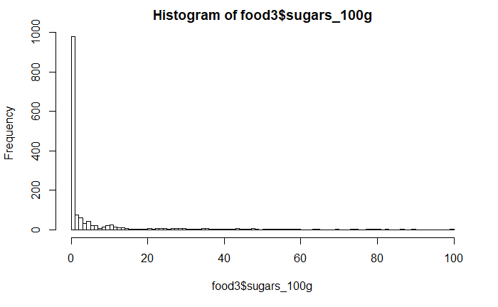

```r
# Find indices of sugar NA values: missing
missing <- is.na(food3$sugars_100g)

# Replace NA values with 0
food3$sugars_100g[missing] <- 0

# Create first histogram
hist(food3$sugars_100g, breaks = 100)
```

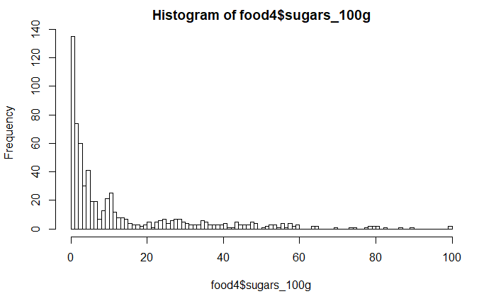

```r
# Create food4
food4 <- food3[food3$sugars_100g > 0, ]

# Create second histogram
hist(food4$sugars_100g, breaks = 100)
```

Excluding the observations which don’t contain any sugar, you can better visualize what the underlying distribution looks like.

### Dealing with messy data

How many of these foods come in some sort of plastic packaging?

The dataset has information about packaging, but there’s a bit of a problem: it’s stored in several different languages (Spanish, French, and English). This takes messy data to a whole new level! There is no R package to selectively translate, but what if you could just work with the messy data directly?

The root word for plastic is same in English (plastic), French (plastique), and Spanish (plastico). To get a general idea of how many of these foods are packaged in plastic, we can look through the packaging column for the string “plasti”.

```r
# Find entries containing "plasti": plastic
plastic <- str_detect(food3$packaging, "plasti")

# Print the sum of plastic
print(sum(plastic))
```

```
[1] 232
```